# Assignment 1

Bongeka Buthelezi

22 February 2017

## Hello Octocat

I love octocat. She’s the coolest cat in town

quick_look

```r
data("anscombe")
dim.data.frame(anscombe)
```

```
## [1] 11  8
```

```r
colnames(anscombe)
```

```
## [1] "x1" "x2" "x3" "x4" "y1" "y2" "y3" "y4"
```

```r
head(anscombe)
```

```
##   x1 x2 x3 x4   y1   y2    y3   y4
## 1 10 10 10  8 8.04 9.14  7.46 6.58
## 2  8  8  8  8 6.95 8.14  6.77 5.76
## 3 13 13 13  8 7.58 8.74 12.74 7.71
## 4  9  9  9  8 8.81 8.77  7.11 8.84
## 5 11 11 11  8 8.33 9.26  7.81 8.47
## 6 14 14 14  8 9.96 8.10  8.84 7.04
```

```r
tail(anscombe)
```

```
##    x1 x2 x3 x4    y1   y2   y3    y4
## 6  14 14 14  8  9.96 8.10 8.84  7.04
## 7   6  6  6  8  7.24 6.13 6.08  5.25
## 8   4  4  4 19  4.26 3.10 5.39 12.50
## 9  12 12 12  8 10.84 9.13 8.15  5.56
## 10  7  7  7  8  4.82 7.26 6.42  7.91
## 11  5  5  5  8  5.68 4.74 5.73  6.89
```

```r
summary(col(anscombe))
```

```
##        V1          V2          V3          V4          V5          V6
##  Min.   :1   Min.   :2   Min.   :3   Min.   :4   Min.   :5   Min.   :6
##  1st Qu.:1   1st Qu.:2   1st Qu.:3   1st Qu.:4   1st Qu.:5   1st Qu.:6
##  Median :1   Median :2   Median :3   Median :4   Median :5   Median :6
##  Mean   :1   Mean   :2   Mean   :3   Mean   :4   Mean   :5   Mean   :6
##  3rd Qu.:1   3rd Qu.:2   3rd Qu.:3   3rd Qu.:4   3rd Qu.:5   3rd Qu.:6
##  Max.   :1   Max.   :2   Max.   :3   Max.   :4   Max.   :5   Max.   :6
##        V7          V8
##  Min.   :7   Min.   :8
##  1st Qu.:7   1st Qu.:8
##  Median :7   Median :8
##  Mean   :7   Mean   :8
##  3rd Qu.:7   3rd Qu.:8
##  Max.   :7   Max.   :8
```

x_y plot

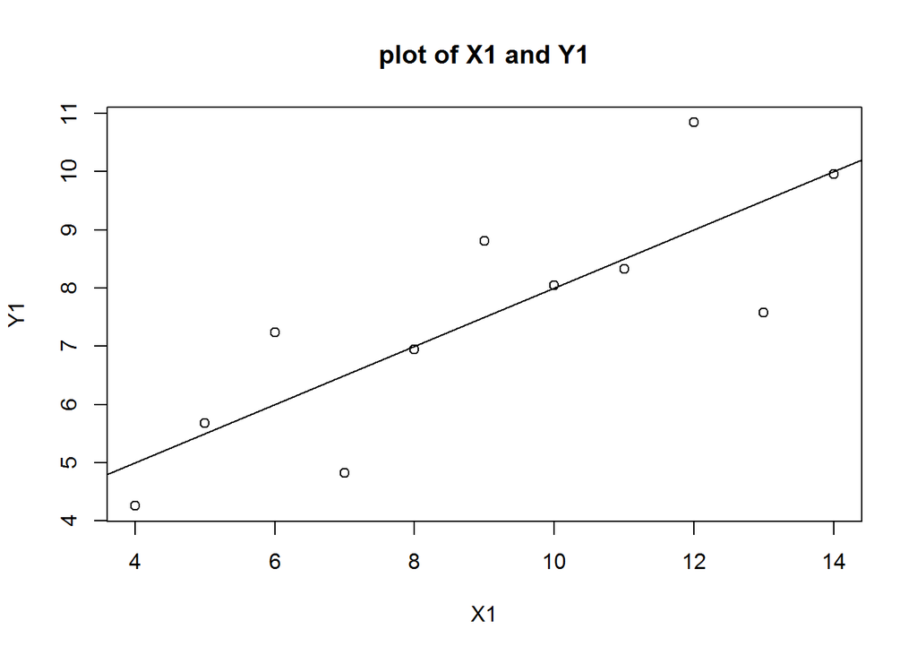

```r
# knitr chunk options
options(echo = FALSE,
               fig.align = "center",
               fig.path = './figures/',
               fig.width = 8,
               fig.height = 8,
               dev = c("svg"))
data("anscombe")
plot(anscombe$x1,anscombe$y1,main = "plot of X1 and Y1",xlab = "X1",ylab = "Y1")
abline(lm(y1 ~ x1, data = anscombe))
```

## assignment 4

quick_look

```r
library(readr)
analgesic <- read_csv("https://dl.dropboxusercontent.com/u/11805474/painblogr/biostats/assignments/analgesic.csv")
View(analgesic)
df <- analgesic
```

data_summary summary of analgesic data

```r
View(analgesic)
"df" <- analgesic
data(df)
dim.data.frame(df)
```

```
## [1] 40  5
```

```r
colnames(df)
```

```
## [1] "ID"            "Group"         "Measurement_1" "Measurement_2"
## [5] "Measurement_3"
```

```r
head(df)
```

```
## # A tibble: 6 × 5
##      ID     Group Measurement_1 Measurement_2 Measurement_3
##   <int>     <chr>         <int>         <int>         <int>
## 1     1 Analgesic            26            26            21
## 2     2 Analgesic            29            26            23
## 3     3 Analgesic            24            28            22
## 4     4 Analgesic            25            22            24
## 5     5 Analgesic            24            28            23
## 6     6 Analgesic            22            23            26
```

```r
tail(df)
```

```
## # A tibble: 6 × 5
##      ID   Group Measurement_1 Measurement_2 Measurement_3
##   <int>   <chr>         <int>         <int>         <int>
## 1    35 Placebo            17            21            15
## 2    36 Placebo            19            17            15
## 3    37 Placebo            14            19            13
## 4    38 Placebo            17            19            13
## 5    39 Placebo            11            20            18
## 6    40 Placebo            15            18            12
```

```r
summary(col(df))
```

```
##        V1          V2          V3          V4          V5
##  Min.   :1   Min.   :2   Min.   :3   Min.   :4   Min.   :5
##  1st Qu.:1   1st Qu.:2   1st Qu.:3   1st Qu.:4   1st Qu.:5
##  Median :1   Median :2   Median :3   Median :4   Median :5
##  Mean   :1   Mean   :2   Mean   :3   Mean   :4   Mean   :5
##  3rd Qu.:1   3rd Qu.:2   3rd Qu.:3   3rd Qu.:4   3rd Qu.:5
##  Max.   :1   Max.   :2   Max.   :3   Max.   :4   Max.   :5
```

data_tidy

```r
library(dplyr)
library(tidyr)
library(readr)
View(analgesic)
gather(analgesic,na.rm = TRUE,convert = TRUE, factor_key = TRUE)
```

```
## # A tibble: 200 × 2
##      key value
##    <chr> <chr>
## 1     ID     1
## 2     ID     2
## 3     ID     3
## 4     ID     4
## 5     ID     5
## 6     ID     6
## 7     ID     7
## 8     ID     8
## 9     ID     9
## 10    ID    10
## # ... with 190 more rows
```

```r
summarise
```

```
## function (.data, ...)
## {
##     summarise_(.data, .dots = lazyeval::lazy_dots(...))
## }
## <environment: namespace:dplyr>
```

## Assignment 5

# Chicken Weights

Null hypothesis: There will be no significant statistical difference between the groups Alternarive hypothesis: There will be a sigificant statistical difference between the groups Statistical test: One-way Anova Assumptions: 1. Gaussian distribution 2. Equal Variances across the groups 3. Unpaired data 4. Errors are independent

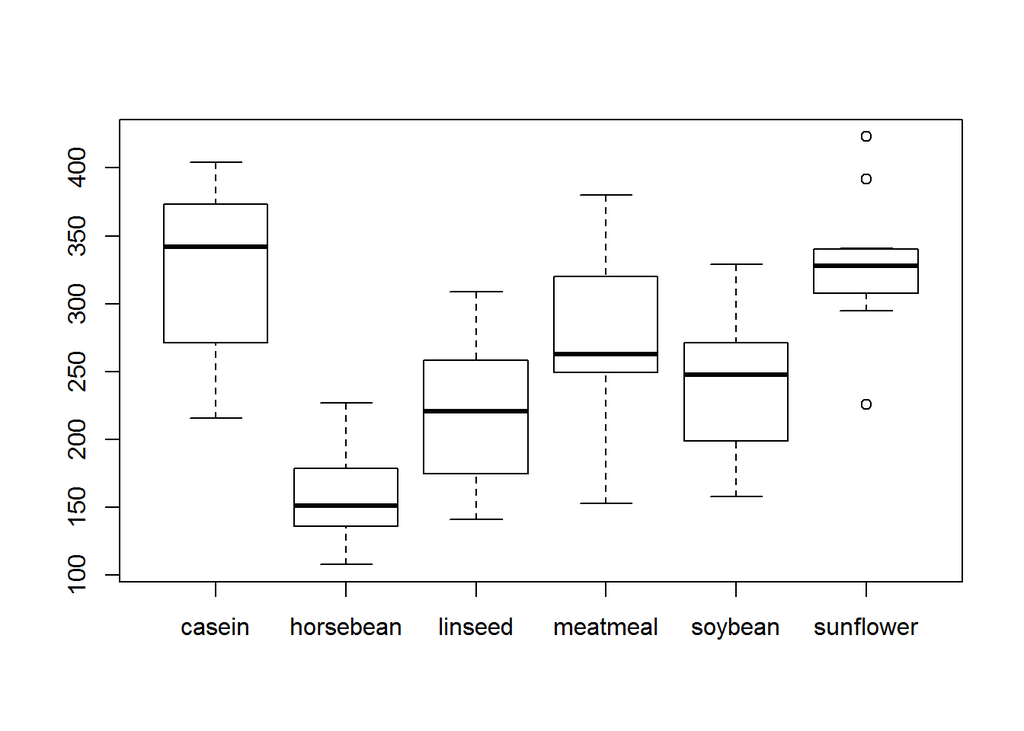

```r
data("chickwts")
boxplot(weight ~ feed, data = chickwts)
```

```r
bar <- aov(weight ~ feed, data = chickwts)
summary(bar)
```

```
##             Df Sum Sq Mean Sq F value   Pr(>F)
## feed         5 231129   46226   15.37 5.94e-10 ***
## Residuals   65 195556    3009
## ---
## Signif. codes:  0 '***' 0.001 '**' 0.01 '*' 0.05 '.' 0.1 ' ' 1
```

Interpretation of results:There is a significant statistical difference to show that the type of feed influeces growth rate.

# The Hot Zone

Null: There is no significant statitical difference between how much water the patients consumed and whether or not they became ill from it Alternative: There is a significant statistical difference between how much contaminated water the patient drank and whether or not they became ill. Statistical test: Chi squared test Assumptions: 1. Randomn sampling 2. Independent observations 3. Large sample

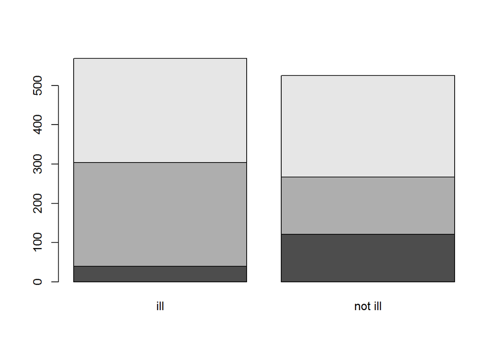

```r
library(readr)
gastroenteritis <- read.csv("C:/Users/Bongeka/Downloads/gastroenteritis.csv")
foo <- gastroenteritis
TAB<-table(foo$Consumption, foo$Outcome)
barplot(TAB)
```

```r
chisq.test(TAB)
```

```
##
##  Pearson's Chi-squared test
##
## data:  TAB
## X-squared = 74.925, df = 2, p-value < 2.2e-16
```

Interpretation of results:There is sufficient statistical evidence to conclude that the amount of contamiated water the patient drank is not independent to the patient becoming ill.

# NAUSEA

```r
library(readr)
nausea <- read_csv("C:/Users/Bongeka/Downloads/nausea.csv")
cols(
  Patient = col_integer(),
  Nausea_before = col_integer(),
  Nausea_after = col_integer()
)
```

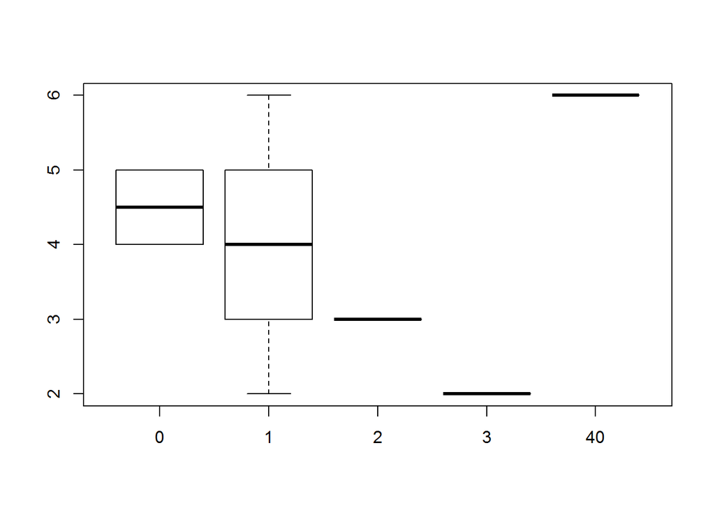

```r
boxplot(nausea$Nausea_before ~nausea$Nausea_after)
```

## Assigment 6

```r
library(readr)
housing_prices <-read_csv("C:/Users/Bongeka/Downloads/housing-prices.csv")
```

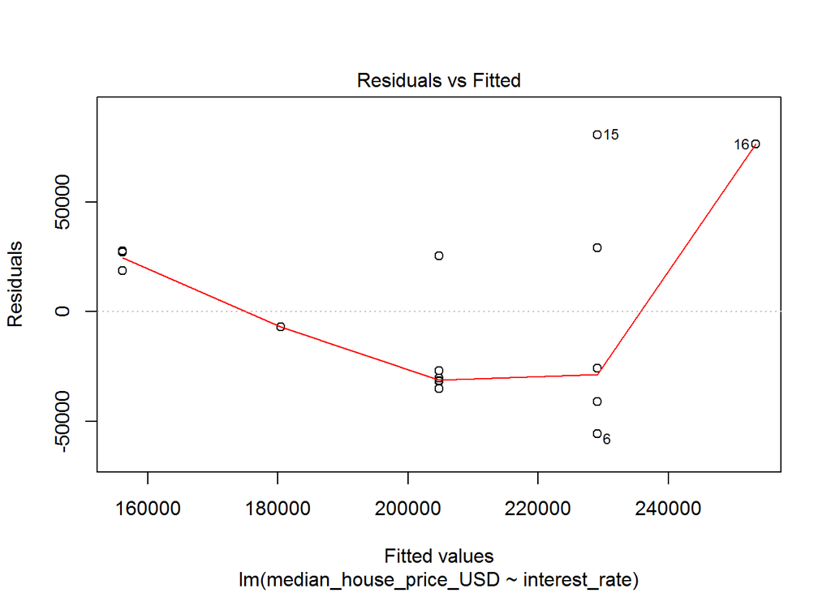

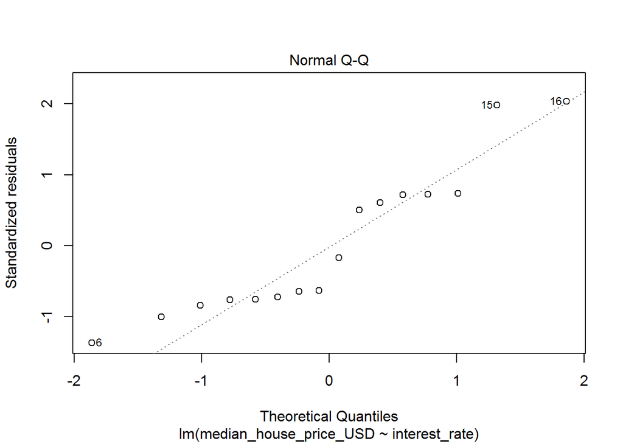

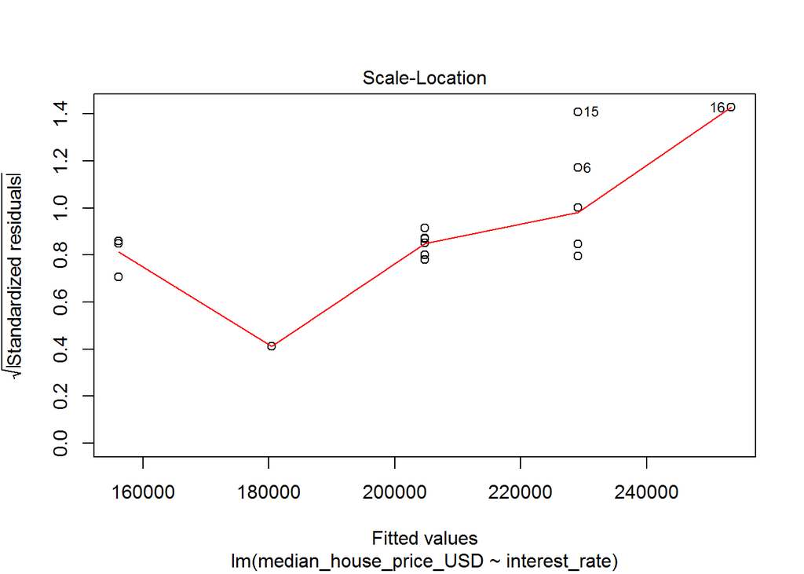

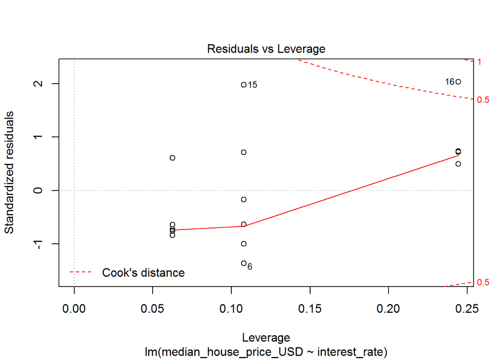

```r
mod <- lm(median_house_price_USD ~ interest_rate, data = housing_prices)
plot(mod)
```

```r
summary(mod)
```

```
##
## Call:
## lm(formula = median_house_price_USD ~ interest_rate, data = housing_prices)
##
## Residuals:
##    Min     1Q Median     3Q    Max
## -55865 -31631 -16406  27212  80735
##
## Coefficients:
##               Estimate Std. Error t value Pr(>|t|)
## (Intercept)     399229      74427   5.364 9.99e-05 ***
## interest_rate   -24309       9205  -2.641   0.0194 *
## ---
## Signif. codes:  0 '***' 0.001 '**' 0.01 '*' 0.05 '.' 0.1 ' ' 1
##
## Residual standard error: 43180 on 14 degrees of freedom
##   (1 observation deleted due to missingness)
## Multiple R-squared:  0.3325, Adjusted R-squared:  0.2848
## F-statistic: 6.974 on 1 and 14 DF,  p-value: 0.01937
```